# Beyond the code

Supporting teams through the transition to open source

Raphaël Simon, Vincent Biot, Nathalie Rigollot, Meriem Saïd  
ATIH

19 November 2026

## ATIH at a glance

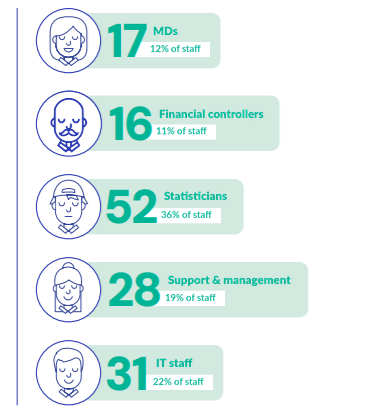

- Mission: collecting, analysing and publishing hospital data
- High data volumes, daily data flows
- Business-critical production systems
- Partners: hospitals, regional health agencies, ministry (DGOS, DREES), researchers, industry

##### 2023: the “alternatives” project kicks off

## Switching software

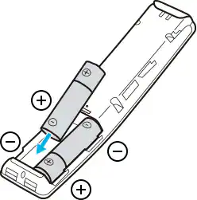

## Switching software

[figure not shown]

25 years of code: nothing translates itself

[figure not shown]

**You might have caught it**

110 billion euros, one deadline, zero regression: migrating a critical calculation service to R with AI

20 %

tools

80 %

People

# Supporting change

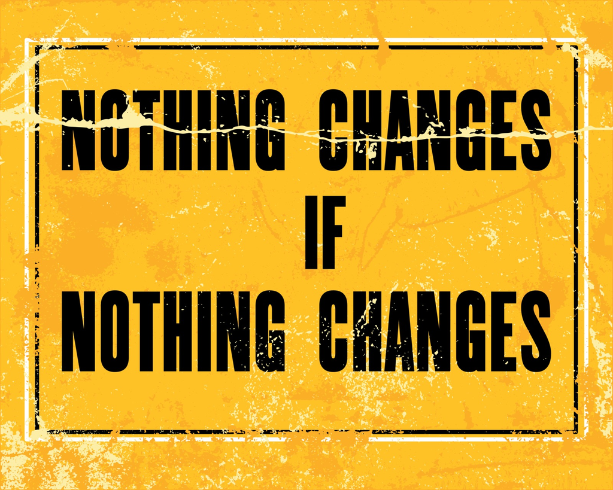

## Governance

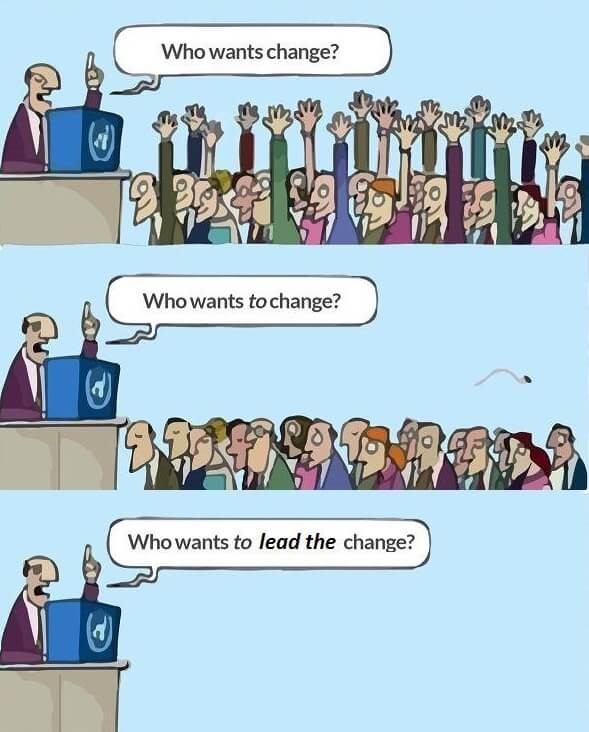

classic steering committee  
senior management decides and arbitrates

classic project team  
a point person in every department

new catalysts  
scout, dig in, test, propose, shake things up

## Professional identity

engineer statistician

## Professional identity

engineer statistician

↓

engineer statistician

data scientistmodel

data analystanalyse

data engineerintegrate

DBAadminister

project managerorchestrate

# Supporting upskilling

## No rungs, just tools

[figure not shown]

With a staircase meant for climbing, one often ends up lower than one would have gone down one meant for descending.

## Investing in individuals

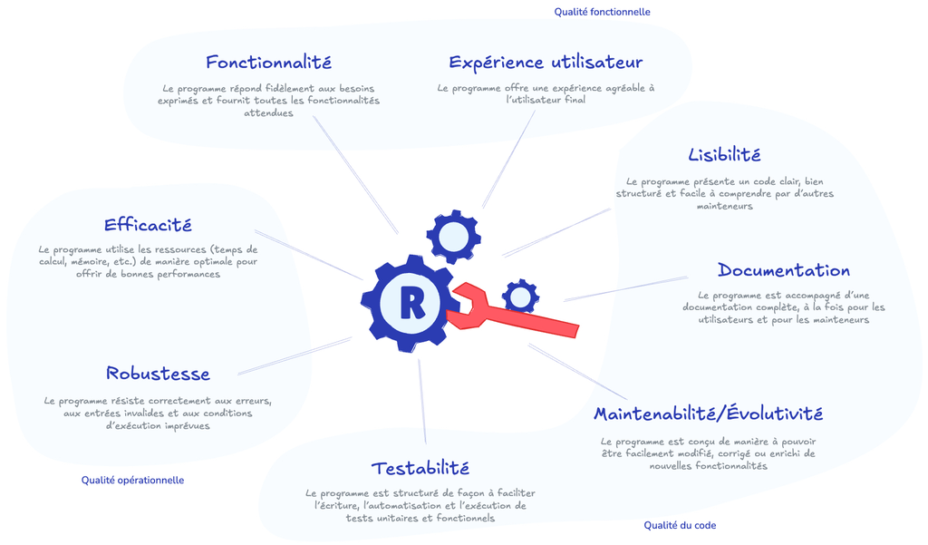

thinkr.fr

## Fostering knowledge sharing

R bubbles

45 min

webinars

~ 2 h

acceleRatihon

several days

Launch - facilitate - renew

# Infrastructure

## Embracing developer culture

[figure not shown]

🔀

version & share

GitCIforge

🔁

reproduce

versionsenvironments

🧩

modularise

functionspackages

## Four years, one step at a time

**Coding / rewriting**

**Scoping**

- Governance
- Mapping

**Coaching**: external, non-technical

**Webinars**

- General updates
- Tech sharing
- Letting off steam

**Coding / rewriting**

**Training**

- R for beginners
- Good practices

**Roadmaps**

**Coaching**: external, non-technical

**Webinars**

**R bubbles**

**Coding / rewriting**

**Training**

- Git
- Packages

**Roadmaps + Jira tracking**

**Coaching**: external, non-technical AND technical

**R bubbles**

**acceleRatihon days**

- Themed workshops
- Cross-cutting topics

**Coding / rewriting**

**Training**

- Functions
- `{targets}`, OOP, …

**Jira tracking**

**Coaching**: external, non-technical AND technical

**R bubbles**

**acceleRatihon days**

- Themed workshops
- Supervised coding
- Masterclasses

## What’s next?

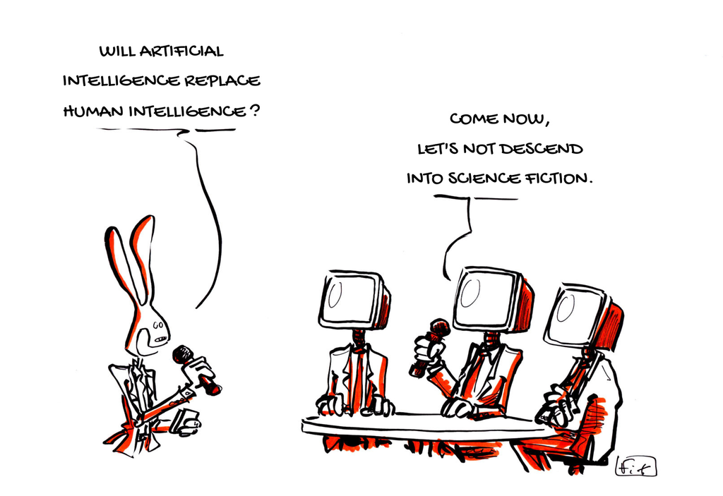

Thank you

raphael.simon@atih.sante.fr